# Wildlife Crime Dashboard

The illegal wildlife trade (IWT) is considered to be one of the largest illegal markets in the world, drawing the attention of numerous organized crime groups (Martínez and Alonso, 2021). This market is estimated to be worth 7-23 billion USD per year (Nellemann et al., 2016). Countries around the world experience wildlife crime with many government agencies working to try to prevent it from occurring. Despite this effort, many species are still targeted for various parts, including rhino ivory, tiger bone marrow, bushmeat, and more. This project helps visualize the number of wildlife trade incidents that are occurring, countries they are most common in, and arrests being made.

Wildlife Crime Trends Over Time

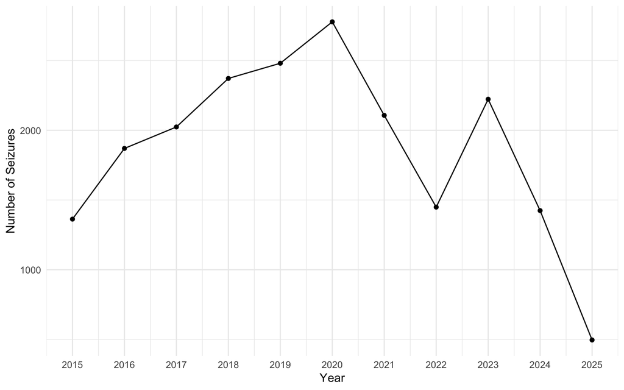

Total Seizures

20587

Total Arrests

27309

Most Common Incident Types

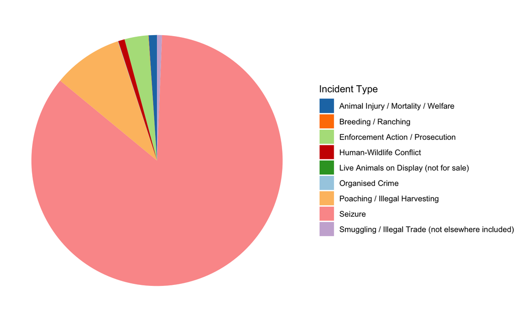

**DATA SUMMARY**

These figures depict the countries where most incidents occur and the distribution of the different types of incidents. China and India have the highest demand for illegal wildlife products and are also home to a lot of high demand species. Most incident types are classified as a seizure and the second most common incident type is poaching / illegal harvesting.

Wildlife Crime Incidents (Top 10 Countries)

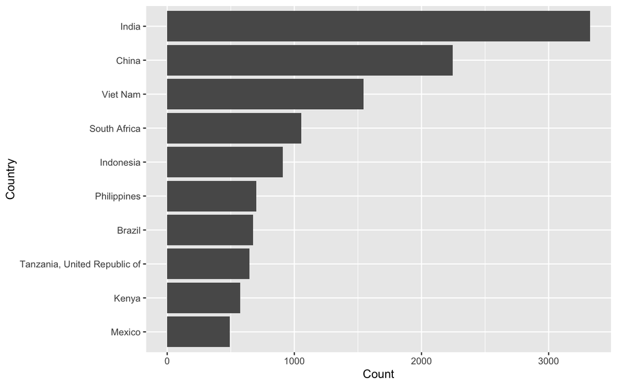

Wildlife Crime Incidents by Country

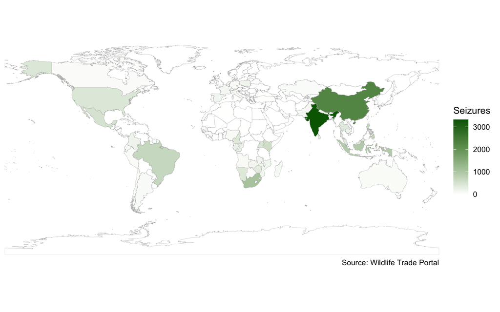

Type of Incident by Country (Top 50)

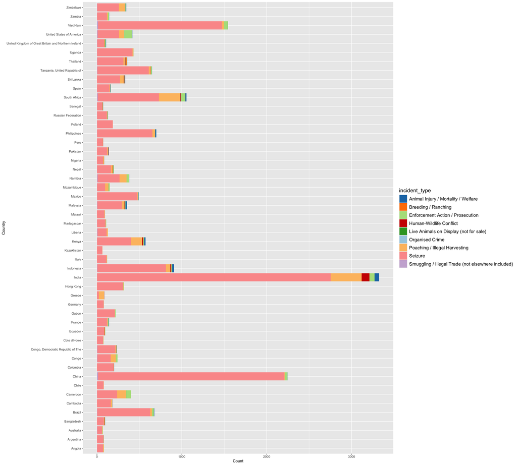

**DATA SUMMARY**

Type of Transport Used for Smuggling

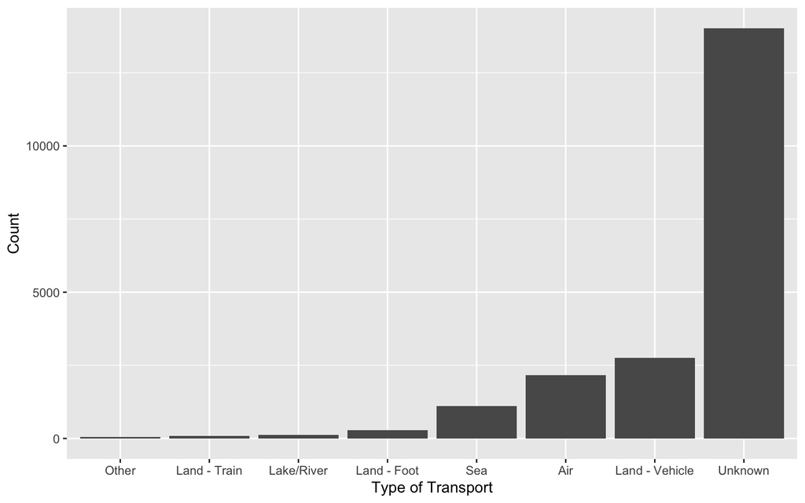

Total Arrests by Country

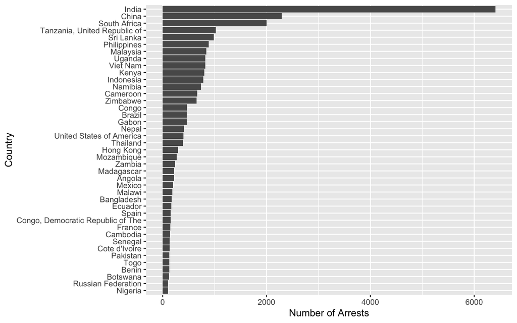

Distribution of Arrest Outcomes

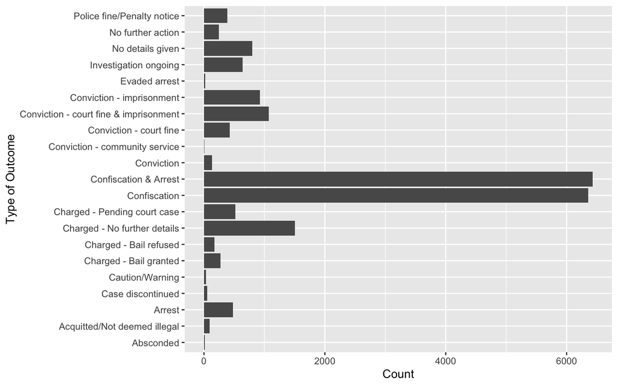

Data is derived from Wildlife Trade Portal and covers the years 2015-2025. This table only shows the first 500 out of 20,587 entries.

[output not shown]

[output cut: 490 more lines]